# GEOG 6000 Lab 08 Spatial Data in R

Simon Brewer

9/2/2020

In this lab, we will explore some of R’s functionality with spatial data, with special attention given to the `sf` package. For more information about `sf`, you can visit their [website](https://r-spatial.github.io/sf/). Robin Lovelace’s book *Geocomputation with R* (available [online](https://geocompr.robinlovelace.net/)) is also a really helpful and educational source for learning `sf`. In fact, much of this lab is just an abbreviated version of that book. For some of the longer examples, it is highly recommended to use R’s scripting functions to run the examples to save on re-typing.

Before starting the lab, you will need to set up a new folder for your working directory. Go to your `geog6000` folder now and create a new folder for today’s class called `lab08`. The following files will be used in this lab, all available on Canvas:

- Climate dataset for Western North America: *WNAclimate.csv*
- Temperature dataset for Oregon in shapefile format: *oregon.zip*
- New York state polygon data in a shapefile: *NY_Data.zip*
- Digital elevation map from Switzerland: *swiss_dem.grd*
- A NetCDF file of global monthly air temperature: *air.mon.ltm.nc*

You will need to download these files from Canvas, and move them from your `Downloads` folder to the `datafiles` folder that you made previously. Make sure to unzip the zip files so that R can access the content. Note that on Windows, you will need to right-click on the file and select ‘Extract files’.

You will also need to install the following packages:

```r
pkgs <- c("ggplot2",
          "mapview",
          "raster",
          "RColorBrewer"
          "sf",
          "tmap",
          "viridis")

install.packages(pkgs)
```

```r
library(ggplot2)
library(mapview)
library(raster)
library(RColorBrewer)
library(sf)
library(tmap)
library(viridis)
```

# Intro to `sf`

### What is `sf`?

`sf` is an R package designed to work with spatial data organized as “simple features” (hence, ‘sf’). Mostly, it supersedes the `sp` package (written by the same people), but it also collapses a lot of other R packages into one. In fact, just a few years ago, if you were to take this course, you would have loaded all of these packages:

```r
library(maptools)
library(rgdal)
library(rgeos)
library(sp)
```

Now, a simple

```r
library(sf)
```

will suffice. The `sf` package is able to provide all the functionality it does because it interfaces with three widely adopted programming standards: PROJ, GDAL, and GEOS. These provide for coordinate reference systems, reading and writing of spatial data, and geometric operations, respectively, but more on this in a moment.

Note that all `sf` functions are prefixed with `st_` (a legacy of this R package’s origins in PostGIS, where ‘st’ means “spatial type”).

### What is a simple feature?

A simple feature is, in the words of the `sf` authors, “a formal standard (ISO 19125-1:2004) that describes how objects in the real world can be represented in computers, with emphasis on the spatial geometry of these objects” ([ref](https://r-spatial.github.io/sf/articles/sf1.html)). In other words, its structured data that provides information about a location in space, including its shape.

The way that `sf` chooses to represent simple features in R should be familiar to you because they are just fancy data.frames:

```r
path_to_data <- system.file("shape/nc.shp", package="sf")

north_carolina <- st_read(path_to_data, quiet = TRUE)

north_carolina <- north_carolina[ , c("CNTY_ID", "NAME", "AREA", "PERIMETER")]

north_carolina
```

```
## Simple feature collection with 100 features and 4 fields
## geometry type:  MULTIPOLYGON
## dimension:      XY
## bbox:           xmin: -84.32385 ymin: 33.88199 xmax: -75.45698 ymax: 36.58965
## geographic CRS: NAD27
## First 10 features:
##    CNTY_ID        NAME  AREA PERIMETER                       geometry
## 1     1825        Ashe 0.114     1.442 MULTIPOLYGON (((-81.47276 3...
## 2     1827   Alleghany 0.061     1.231 MULTIPOLYGON (((-81.23989 3...
## 3     1828       Surry 0.143     1.630 MULTIPOLYGON (((-80.45634 3...
## 4     1831   Currituck 0.070     2.968 MULTIPOLYGON (((-76.00897 3...
## 5     1832 Northampton 0.153     2.206 MULTIPOLYGON (((-77.21767 3...
## 6     1833    Hertford 0.097     1.670 MULTIPOLYGON (((-76.74506 3...
## 7     1834      Camden 0.062     1.547 MULTIPOLYGON (((-76.00897 3...
## 8     1835       Gates 0.091     1.284 MULTIPOLYGON (((-76.56251 3...
## 9     1836      Warren 0.118     1.421 MULTIPOLYGON (((-78.30876 3...
## 10    1837      Stokes 0.124     1.428 MULTIPOLYGON (((-80.02567 3...
```

You can summarize this somewhat verbose printout by noting that simple features fit a simple formula:

$$sf = attributes + geometry + crs$$

This formula also sugests the kinds of ways that you might interact with an `sf` object by, for example, changing its crs, or filtering based on its attributes (or geometry), or manipulating its geometry.

##### **Attributes**

*Attributes* are properties of a feature. In this case, the features are counties in North Carolina, and their attributes are things like name and area. In an `sf` data.frame, **each feature is a row, and each attribute is a column**. In the `north_carolina` object, for example, the first feature has the name “Ashe” and its county ID is 1825.

##### **Geometry**

A very special attribute column is called the *geometry* (sometimes labeled ‘geom’ or ‘shape’). It consists of a point or set of points (specifically, their coordinates) that define the shape and location of the feature. The simple feature standard includes 17 geometry types, 7 of which are supported by `sf`: point, multipoint, linestring, multilinestring, polygon, multipolygon, and geometry collection.

As mentioned already, these geometries are just a series of points:

```r
point_one <- st_point(c(0, 3))

point_two <- st_point(c(5, 7))

a_line <- st_linestring(c(point_one, point_two))
```

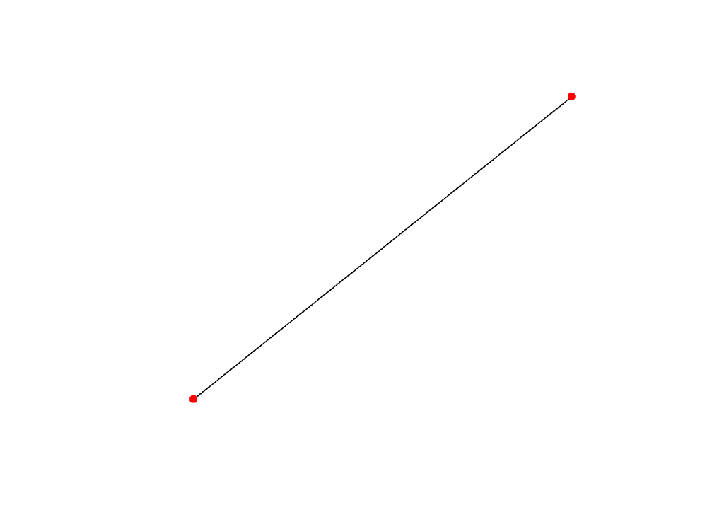

If you print these geometries

```r
point_one
```

```
## POINT (0 3)
```

```r
a_line
```

```
## LINESTRING (0 3, 5 7)
```

you see that they are represented as a text string. This is the [Well Known Text](https://en.wikipedia.org/wiki/Well-known_text_representation_of_geometry) (WKT) standard for specifying geometries. It tells us what kind of geometry the feature is and lists its x-y coordinates separated by commas.

If you want to know what geometry type your simple feature contains, try:

```r
st_geometry_type(a_line)
```

```
## [1] LINESTRING
## 18 Levels: GEOMETRY POINT LINESTRING POLYGON MULTIPOINT ... TRIANGLE
```

##### **CRS**

The final ingredient in a simple feature is its a spatial or [*coordinate reference system*](https://en.wikipedia.org/wiki/Spatial_reference_system) (CRS). A CRS provides two crucial pieces of information: (i) what rule we use to assign coordinates to points and (ii) what datum to use. It is not an exaggeration to say that **the CRS is the most important element of a simple feature**, for without a CRS, the numbers in the geometry column are just that, numbers, rather than full-blooded *spatial* coordinates.

Understanding what a coordinate assignment rule does is beyond the scope of this lab, but the datum deserves some attention. In effect, it specifies three things:

1. the origin or the point on the earth’s surface where the coordinates are `POINT (0 0)`,
2. the scale of the coordinates, for example, whether we should think of `POINT (5 7)` as being 5 *meters* east and seven *meters* north of the origin, or - worse - 5 *feet* east and 7 *feet* north, and
3. the orientation of the system, or which way is up?

As with the geometries, the standard for representing CRS is WKT, though the easiest way to identify a CRS is to use its EPSG code. To find the EPSG code for a CRS, you can visit this website: [spatialreference.org](https://spatialreference.org/).

The most widely used CRS is the World Geodetic System 84 (WGS 84, a geographic system) whose EPSG code is 4326:

```r
st_crs(4326)
```

```
## Coordinate Reference System:
##   User input: EPSG:4326
##   wkt:
## GEOGCRS["WGS 84",
##     DATUM["World Geodetic System 1984",
##         ELLIPSOID["WGS 84",6378137,298.257223563,
##             LENGTHUNIT["metre",1]]],
##     PRIMEM["Greenwich",0,
##         ANGLEUNIT["degree",0.0174532925199433]],
##     CS[ellipsoidal,2],
##         AXIS["geodetic latitude (Lat)",north,
##             ORDER[1],
##             ANGLEUNIT["degree",0.0174532925199433]],
##         AXIS["geodetic longitude (Lon)",east,
##             ORDER[2],
##             ANGLEUNIT["degree",0.0174532925199433]],
##     USAGE[
##         SCOPE["unknown"],
##         AREA["World"],
##         BBOX[-90,-180,90,180]],
##     ID["EPSG",4326]]
```

If you are familiar with the PROJ4-string syntax, you can retrieve that from a CRS with:

```r
st_crs(4326)$proj4string
```

```
## [1] "+proj=longlat +datum=WGS84 +no_defs"
```

However, current open standards specified by PROJ and GDAL discourage the use of PROJ4-string syntax in favor of WKT, so it is probably best to get use to the latter now.

##### **Bounding Box**

There’s actually one more element to a simple feature, but it is not as vital as the others and is really already implicit in the geometry. That is the bounding box. This is an object defined by the spatial extent of the data: the minimum and maximum x and y coordinates. You can retrieve the bounding box of a simple feature this way:

```r
st_bbox(north_carolina)
```

```
##      xmin      ymin      xmax      ymax
## -84.32385  33.88199 -75.45698  36.58965
```

There are myriad uses for the bounding box, though we need not dwell on them here.

# Read and Write

Reading and writing spatial data, it turns out, is quiet the chore. The solution `sf` relies on is to interface with GDAL, which handles lots of different spatial data types (it’s kinda its whole purpose). Currently supported (vector) spatial data types can be found at [GDAL.org](https://gdal.org/drivers/vector/index.html). Perhaps the most common spatial data type - because ESRI is a thing - is the shapefile, which has a *.shp* file extension.

### Reading in spatial data

In `sf`, the function for reading in spatial data is `st_read`. Here is the nitty-gritty and, perhaps, needlessly verbose version first:

```r
NY8 <- st_read(dsn = "../datafiles/NY_data/NY8_utm18.shp",
               layer = "NY8_utm18",
               drivers = "ESRI Shapefile")
```

```
## options:        ESRI Shapefile
```

`dsn` stands for “data source name” and specifies where the data is coming from, whether a file directory, a database, or something else. `layer` is the layer in the data source to be read in. Finally, `drivers` tells GDAL what format the file is in or what structure it has, so it knows how to correctly interpret the file. All of this information is printed to the console when you execute `st_read`.

In this case, we are using a simple ESRI shapefile, so the data source and layer are basically the same thing. Furthermore, `sf` is good at guessing the driver based on the file extension, so the driver does not normally need to be specified. Hence, we could just as well have written:

```r
NY8 <- st_read("../datafiles/NY_data/NY8_utm18.shp")
```

And here’s what this looks like:

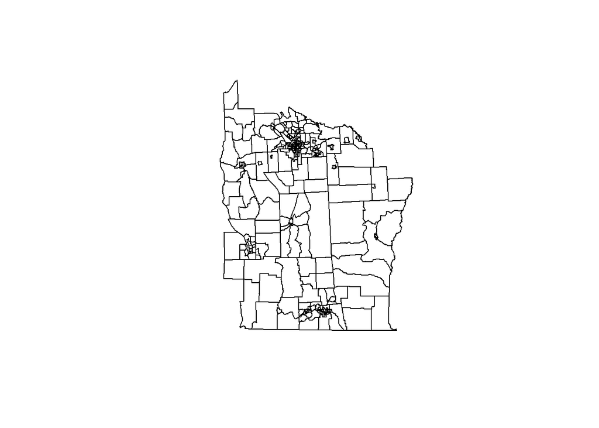

### Converting non-spatial data to simple features

Sometimes you have spatial data, but it is not in a spatial data format. Usually, this means you have a table or spreadsheet with columns for the x and y coordinates.

```r
wna_climate <- read.csv("../datafiles/WNAclimate.csv")

head(wna_climate)
```

```
##   WNASEQ     LONDD   LATDD ELEV totsnopt annp Jan_Tmp Jul_Tmp
## 1      1 -107.9333 50.8736  686  78.7869  326   -13.9    18.8
## 2      2 -105.2670 55.2670  369 145.3526  499   -21.3    16.8
## 3      3 -102.5086 41.7214 1163  42.6544  450    -4.2    23.3
## 4      4 -110.2606 44.2986 2362 255.1009  489   -10.9    14.1
## 5      5 -114.1500 59.2500  880 164.8924  412   -23.9    14.4
## 6      6 -120.6667 57.4500  900 141.9260  451   -17.5    13.8
```

This can be converted to a simple feature using the `st_as_sf` function like so:

```r
wna_climate <- st_as_sf(wna_climate,
                        coords = c("LONDD", "LATDD"),
                        crs = 4326)

wna_climate
```

```
## Simple feature collection with 2012 features and 6 fields
## geometry type:  POINT
## dimension:      XY
## bbox:           xmin: -138 ymin: 29.8333 xmax: -100 ymax: 60
## geographic CRS: WGS 84
## First 10 features:
##    WNASEQ ELEV totsnopt annp Jan_Tmp Jul_Tmp                  geometry
## 1       1  686  78.7869  326   -13.9    18.8 POINT (-107.9333 50.8736)
## 2       2  369 145.3526  499   -21.3    16.8   POINT (-105.267 55.267)
## 3       3 1163  42.6544  450    -4.2    23.3 POINT (-102.5086 41.7214)
## 4       4 2362 255.1009  489   -10.9    14.1 POINT (-110.2606 44.2986)
## 5       5  880 164.8924  412   -23.9    14.4     POINT (-114.15 59.25)
## 6       6  900 141.9260  451   -17.5    13.8   POINT (-120.6667 57.45)
## 7       7 1100 183.4187  492   -18.8    13.2 POINT (-119.7167 56.7167)
## 8       8 1480 191.5657  606   -11.0    12.8    POINT (-114.6 50.7667)
## 9       9  651 144.9015  443   -22.4    15.3 POINT (-122.1667 59.5167)
## 10     10  725 151.0778  455   -23.5    15.4    POINT (-112.1 57.7667)
```

The function just needs to know what columns the x and y coordinates are in and what CRS they are specified in. And here’s what it looks like:

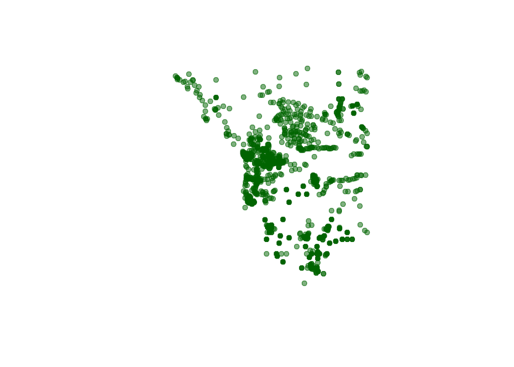

### Writing spatial data

The `sf` function for writing simple features to disk is `st_write`. It is almost an exact mirror of `st_read`, but it also requires that you specify the simple feature object in your R environment that you want to write to disk. If the layer already exists, you will need to specify `delete_layer = TRUE`.

```r
st_write(obj = wna_climate,
         dsn = "../datafiles/wnaclim.shp",
         layer = "wnaclim",
         drivers = "ESRI Shapefile")
```

or, more simply:

```r
st_write(wna_climate, dsn = "../datafiles/wnaclim.shp")
```

# CRS operations

**The uber-rule for working with any spatial data is to make sure all of it is in the same CRS.** Never ever ever ever do anything with your data until you are sure you’ve got the CRS right.

### Check CRS

```r
st_crs(NY8)
```

```
## Coordinate Reference System:
##   User input: WGS 84 / UTM zone 18N
##   wkt:
## PROJCRS["WGS 84 / UTM zone 18N",
##     BASEGEOGCRS["WGS 84",
##         DATUM["D_unknown",
##             ELLIPSOID["WGS84",6378137,298.257223563,
##                 LENGTHUNIT["metre",1,
##                     ID["EPSG",9001]]]],
##         PRIMEM["Greenwich",0,
##             ANGLEUNIT["Degree",0.0174532925199433]]],
##     CONVERSION["UTM zone 18N",
##         METHOD["Transverse Mercator",
##             ID["EPSG",9807]],
##         PARAMETER["Latitude of natural origin",0,
##             ANGLEUNIT["Degree",0.0174532925199433],
##             ID["EPSG",8801]],
##         PARAMETER["Longitude of natural origin",-75,
##             ANGLEUNIT["Degree",0.0174532925199433],
##             ID["EPSG",8802]],
##         PARAMETER["Scale factor at natural origin",0.9996,
##             SCALEUNIT["unity",1],
##             ID["EPSG",8805]],
##         PARAMETER["False easting",500000,
##             LENGTHUNIT["metre",1],
##             ID["EPSG",8806]],
##         PARAMETER["False northing",0,
##             LENGTHUNIT["metre",1],
##             ID["EPSG",8807]],
##         ID["EPSG",16018]],
##     CS[Cartesian,2],
##         AXIS["(E)",east,
##             ORDER[1],
##             LENGTHUNIT["metre",1,
##                 ID["EPSG",9001]]],
##         AXIS["(N)",north,
##             ORDER[2],
##             LENGTHUNIT["metre",1,
##                 ID["EPSG",9001]]]]
```

You can also check the EPSG code (if specified):

```r
st_crs(NY8)$epsg
```

```
## [1] NA
```

```r
st_crs(wna_climate)$epsg
```

```
## [1] 4326
```

And you can get the name of a CRS this way:

```r
format(st_crs(NY8))
```

```
## [1] "WGS 84 / UTM zone 18N"
```

### Set CRS

Two methods: `st_crs<-` and `st_set_crs`.

```r
wna_climate <- st_set_crs(wna_climate, 4326)

st_crs(wna_climate) <- 4326

# st_crs(wna_climate)
```

Note: this should only be used when the simple feature is missing a CRS and you know what it is. It is **NOT** for *changing* the CRS.

### Transform CRS

```r
# st_crs(NY8)

NY8 <- st_transform(NY8, crs = 4326)

# st_crs(NY8)
```

Note: 99.99% of the time, when you read in spatial data, `st_transform` is the first thing you should do to it.

# Attribute operations

The `sf` object is a data.frame, so working with attributes works just the same.

```r
oregon_tann <- read_sf("../datafiles/oregon/oregontann.shp")

oregon_tann
```

```
## Simple feature collection with 92 features and 4 fields
## geometry type:  POINT
## dimension:      XY
## bbox:           xmin: -124.567 ymin: 42.05 xmax: -116.967 ymax: 46.15
## CRS:            NA
## # A tibble: 92 x 5
##    elevation  tann coords_x1 coords_x2          geometry
##        <int> <dbl>     <dbl>     <dbl>           <POINT>
##  1       846   9.6     -121.      44.9 (-120.717 44.917)
##  2        96  12.5     -120.      45.7   (-120.2 45.717)
##  3       543  11.1     -123.      42.2 (-122.717 42.217)
##  4         2  10.3     -124.      46.2  (-123.883 46.15)
##  5      1027   7.6     -118.      44.8 (-117.817 44.833)
##  6      1050   8.4     -118.      44.8 (-117.833 44.783)
##  7        24  10.8     -124.      43.1 (-124.383 43.117)
##  8      1097   7.7     -121.      44.1 (-121.317 44.067)
##  9       999   9.5     -118.      43.9 (-118.167 43.917)
## 10        18  11.2     -122.      45.6  (-121.95 45.633)
## # ... with 82 more rows
```

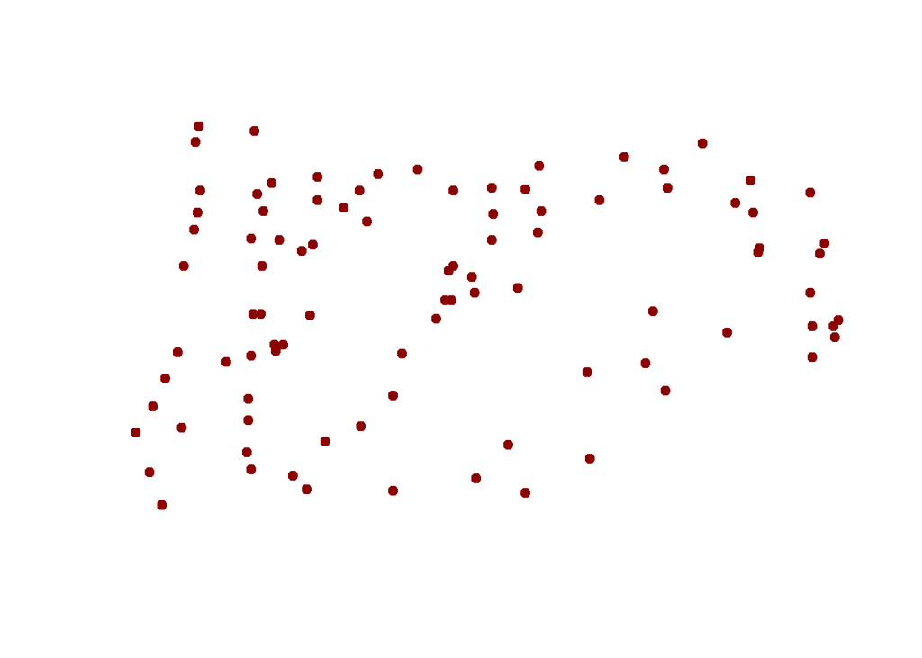

### Select Columns

```r
# get elevation and tann columns

# method 1
oregon_tann2 <- oregon_tann[ , c("elevation", "tann")]

# method 2
oregon_tann2 <- subset(oregon_tann, select = c(elevation, tann))

names(oregon_tann)
```

```
## [1] "elevation" "tann"      "coords_x1" "coords_x2" "geometry"
```

```r
names(oregon_tann2)
```

```
## [1] "elevation" "tann"      "geometry"
```

Notice this very important difference between regular data.frames and `sf` data.frames: when you subset by columns, even though you do not explicitly state that you want to keep the geometry column, it keeps that column anyway. In this sense, the geometry column is said to be “sticky.”

### Filter Rows

```r
# get features above 1000 meters

# method 1
oregon_tann3 <- oregon_tann[oregon_tann$elevation > 1000, ]

# method 2
oregon_tann3 <- subset(oregon_tann, subset = elevation > 1000)
```

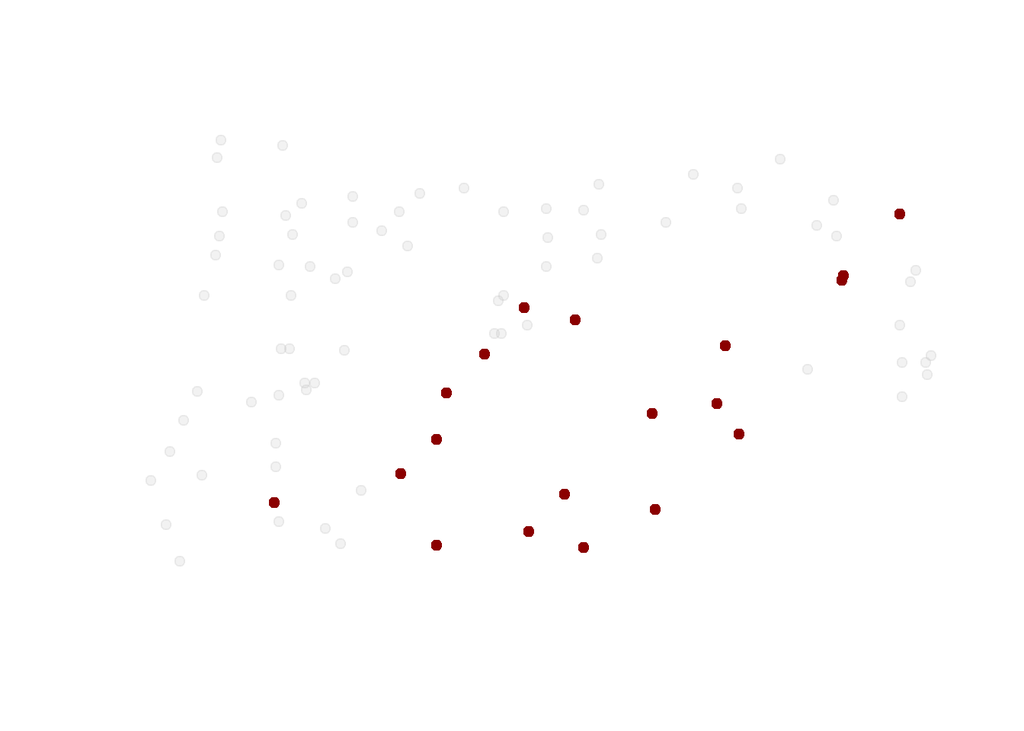

### Add Column

```r
# method 1
oregon_tann$rando <- runif(n = nrow(oregon_tann))

# method 2
oregon_tann[, "rando"] <- runif(n = nrow(oregon_tann))

names(oregon_tann)
```

```
## [1] "elevation" "tann"      "coords_x1" "coords_x2" "geometry"  "rando"
```

### Extract Column

This is for extracting a column to a vector.

```r
# method 1
elevation <- oregon_tann[ , "elevation", drop = TRUE]

# if you don't specify drop = TRUE, it'll keep the sticky geometry column

# method 2
elevaton <- oregon_tann$elevation

elevation[1:10]
```

```
##  [1]  846   96  543    2 1027 1050   24 1097  999   18
```

### Get Geometry

```r
# method 1
geometry <- st_geometry(oregon_tann)

# method 2
geometry <- oregon_tann$geometry

geometry
```

```
## Geometry set for 92 features
## geometry type:  POINT
## dimension:      XY
## bbox:           xmin: -124.567 ymin: 42.05 xmax: -116.967 ymax: 46.15
## CRS:            NA
## First 5 geometries:
```

```
## POINT (-120.717 44.917)
```

```
## POINT (-120.2 45.717)
```

```
## POINT (-122.717 42.217)
```

```
## POINT (-123.883 46.15)
```

```
## POINT (-117.817 44.833)
```

### Drop Geometry

In case you just want the attributes, not the geometry:

```r
attributes <- st_drop_geometry(oregon_tann)

head(attributes)
```

```
## # A tibble: 6 x 5
##   elevation  tann coords_x1 coords_x2  rando
##       <int> <dbl>     <dbl>     <dbl>  <dbl>
## 1       846   9.6     -121.      44.9 0.625
## 2        96  12.5     -120.      45.7 0.111
## 3       543  11.1     -123.      42.2 0.987
## 4         2  10.3     -124.      46.2 0.131
## 5      1027   7.6     -118.      44.8 0.724
## 6      1050   8.4     -118.      44.8 0.0688
```

Note: this is actually a special sort of `data.frame` called a `tibble`. Not important to know about here, but does print slightly differently.

# Spatial operations

Spatial operations are like attribute operations, but they work with the geometry column rather than the attributes. There are loads of these functions, but will just review some of the more important ones here.

### Spatial Filter

This is probably the biggest one. Basically, you are taking one geometry and using it to filter other geometries. To demonstrate this, first we’ll make some random points in the `north_carolina` simple feature. Well, first-first, we need to project the simple features, since `sf` will protest if you try to do spatial operations on longitude and latitude.

```r
north_carolina <- st_transform(north_carolina, crs = 26918)

set.seed(1234)

random_pnts <- st_sample(north_carolina, size = 500)

random_pnts <- st_as_sf(random_pnts)
```

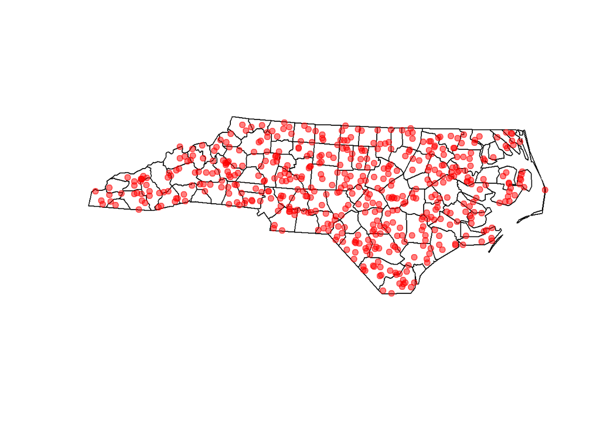

Now, we can collect just the points in, say, Pasquotank County.

```r
pasquotank <- subset(north_carolina, NAME == "Pasquotank")
```

```r
filtered_pnts <- st_filter(random_pnts, pasquotank)
```

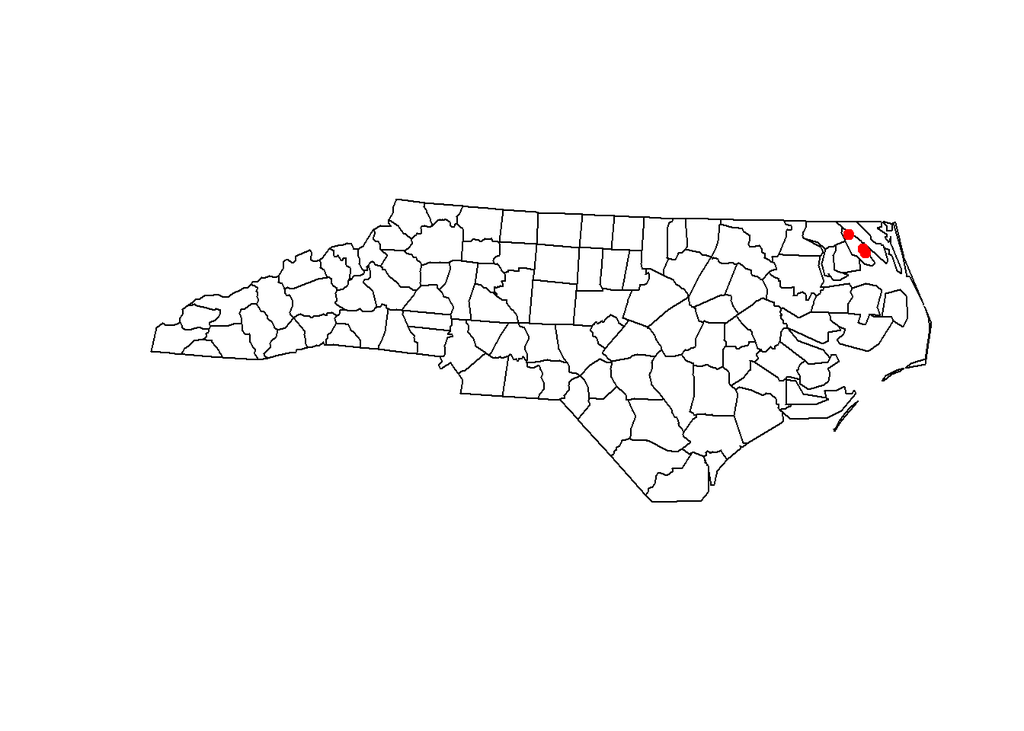

Now, you know where Pasquotank County is!

##### **Topological Relations**

Internally, `st_filter` assumes a “topological” or spatial relationship defined by what the `sf` authors refer to as spatial predicate (`.predicate`), specifically, `st_intersects` (simplifying somewhat, that one geometry is inside the other), but we can specify other spatial relationships, too. For example, all the points *outside* Pasquotank:

```r
filtered_pnts <- st_filter(random_pnts, pasquotank, .predicate = st_disjoint)
```

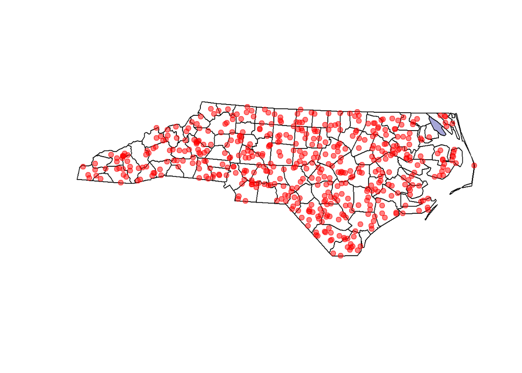

Another useful predicate is `st_is_within_distance`, which requires that you pass an additional distance (`dist`) argument to the filter. The `dist` argument is in units specified by the CRS, in this case meters.

```r
filtered_pnts <- st_filter(random_pnts,
                           pasquotank,
                           .predicate = st_is_within_distance,
                           dist = 50000)
```

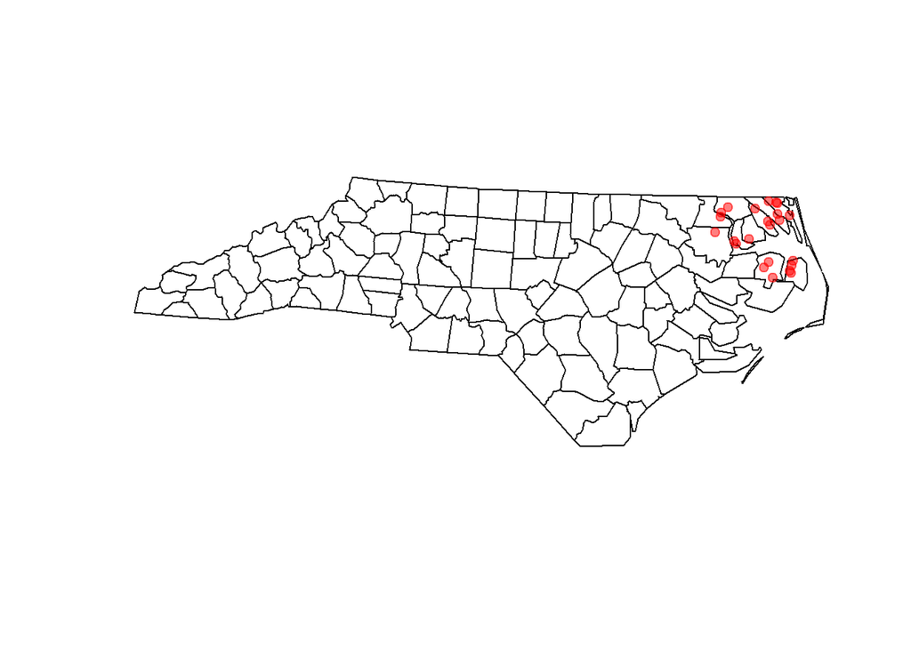

# Geometric operations

With spatial operations, the geometry is preserved (mostly). With geometric operations, the whole point is to manipulate the geometry. Again, we are just going to hit the highlights. It is worth emphasizing that **these operations will often behave differently depending on the geometry type**.

### Centroid

```r
the_heart_of_pasquotank <- st_centroid(pasquotank)
```

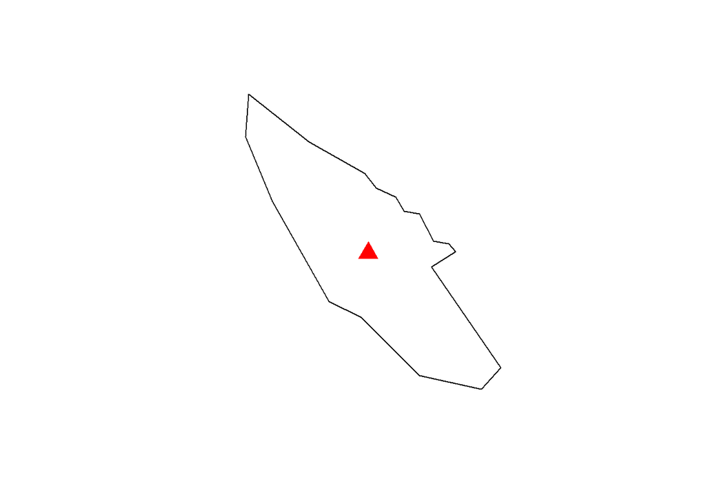

### Buffer

```r
the_heft_of_pasquotank <- st_buffer(pasquotank, dist = 50000)
```

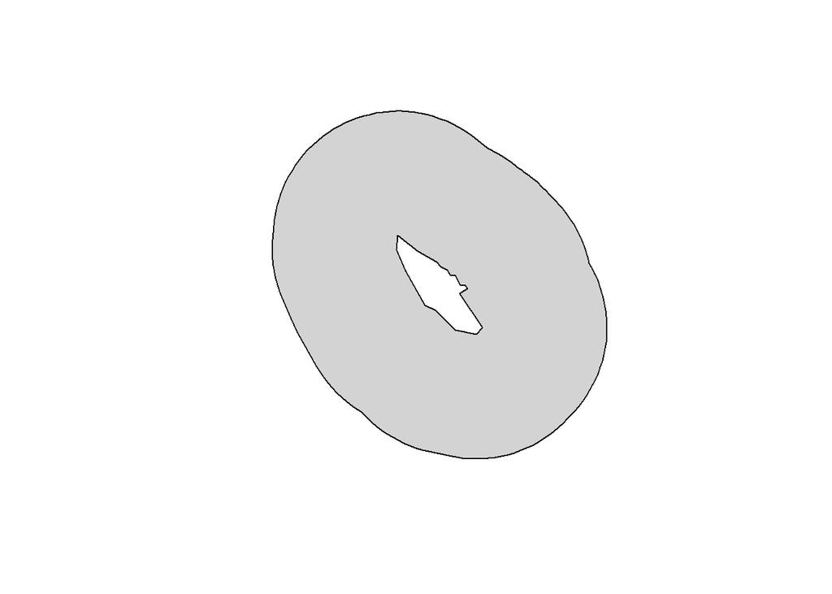

### Union

This one merges geometries and dissolves interior borders when applied to polygons.

```r
north_carolina_boundary <- st_union(north_carolina)
```

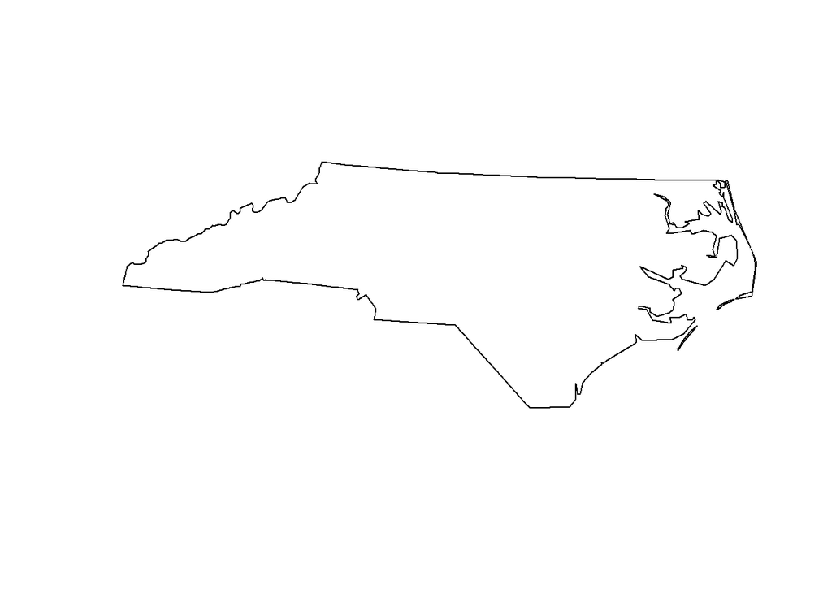

### Cast

To cast a geometry is to change it from one geometry type to another.

```r
north_carolina_points <- st_cast(north_carolina_boundary, "POINT")
```

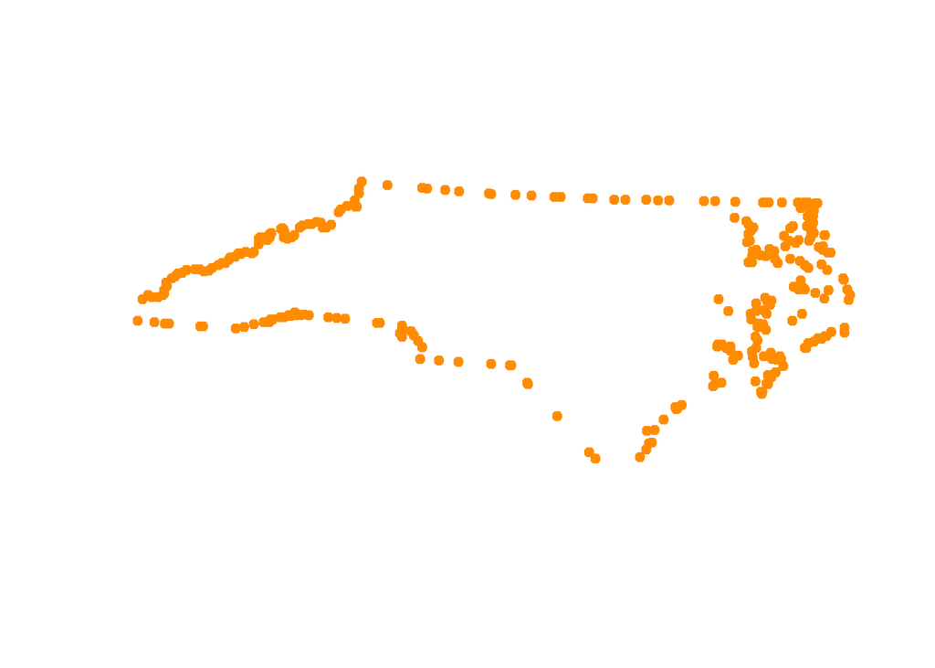

```r
north_carolina_lines <- st_cast(north_carolina_boundary, "MULTILINESTRING")

north_carolina_lines <- st_cast(north_carolina_lines, "LINESTRING")
```

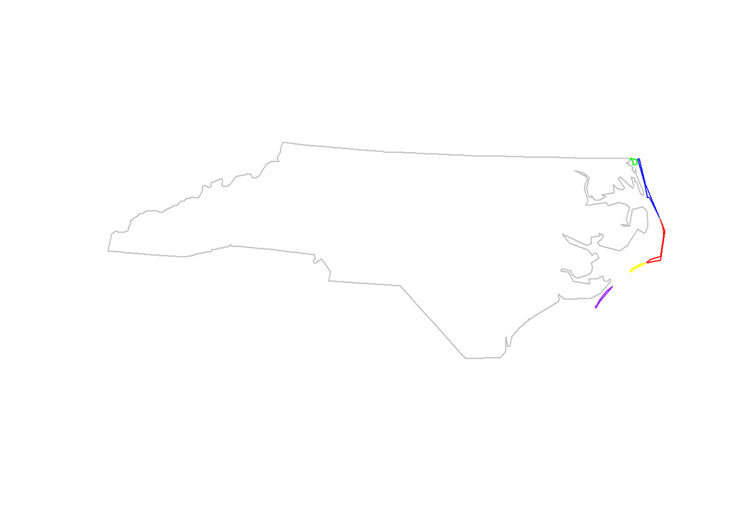

If you can’t tell, it was broken into six lines: one for the mainland, and the other five for the ecological (and cultural) disaster known as the Outer Banks.

# Plotting

### `graphics`

Using the base R `graphics` package.

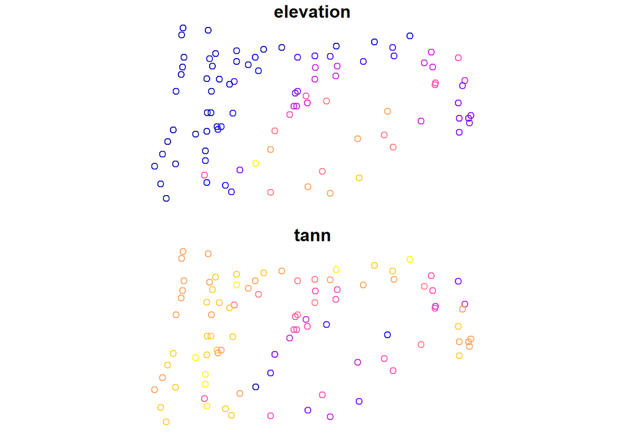

```r
plot(oregon_tann2)
```

Notice that it creates separate plots for each attribute. If you would prefer to plot the geometry itself, you have to say so explicitly.

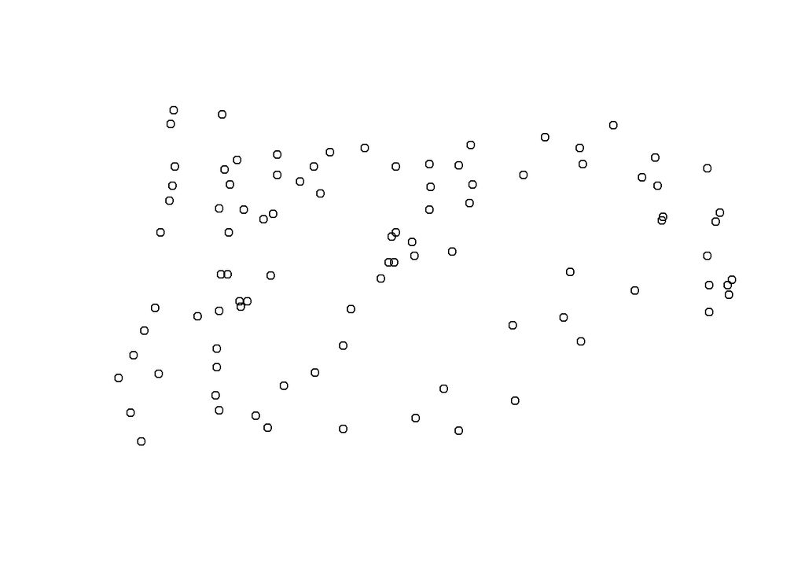

```r
plot(st_geometry(oregon_tann2))
```

### `ggplot2`

The heart of plotting `sf` objects with `ggplot2` is the special plotting geometry, `geom_sf`.

```r
binghamton <- subset(NY8, AREANAME == "Binghamton city")
```

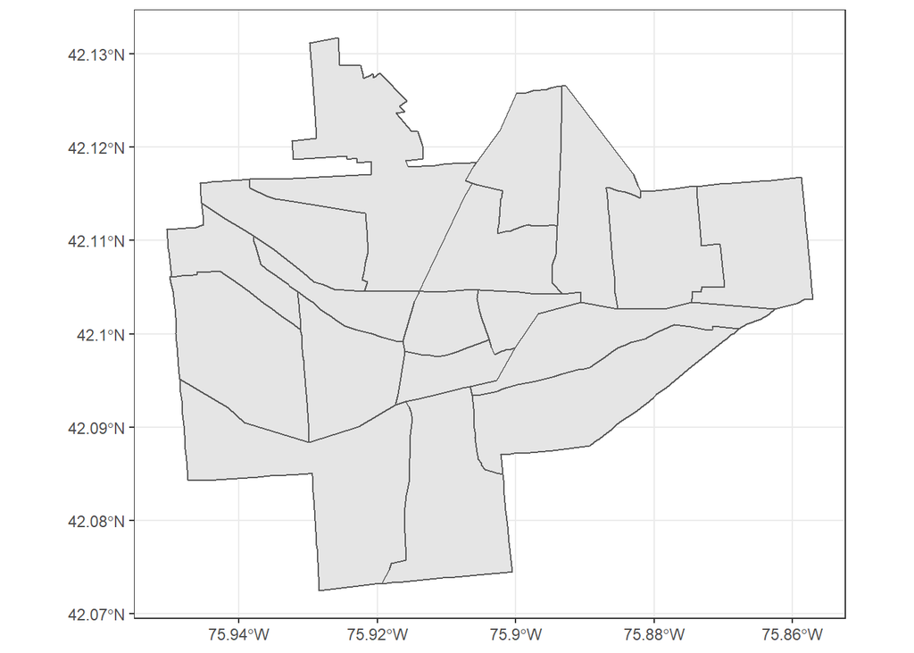

```r
ggplot() +
  geom_sf(data = binghamton) +
  theme_bw()
```

##### **Multiple Geometries**

```r
bingies_neighbors <- st_filter(NY8, binghamton)

random_pnts <- st_sample(bingies_neighbors, size = 25)

random_pnts <- st_as_sf(random_pnts)
```

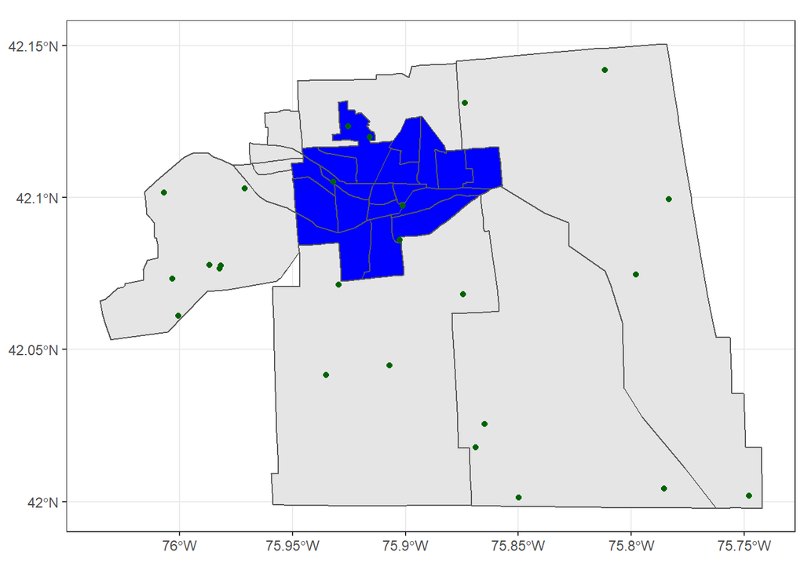

```r
ggplot() +
  geom_sf(data = bingies_neighbors) +
  geom_sf(data = binghamton, fill = "blue") +
  geom_sf(data = random_pnts, color = "darkgreen") +
  theme_bw()
```

##### **Aesthetics**

```r
names(binghamton)
```

```
##  [1] "AREANAME"   "AREAKEY"    "X"          "Y"          "POP8"
##  [6] "TRACTCAS"   "PROPCAS"    "PCTOWNHOME" "PCTAGE65P"  "Z"
## [11] "AVGIDIST"   "PEXPOSURE"  "Cases"      "Xm"         "Ym"
## [16] "Xshift"     "Yshift"     "geometry"
```

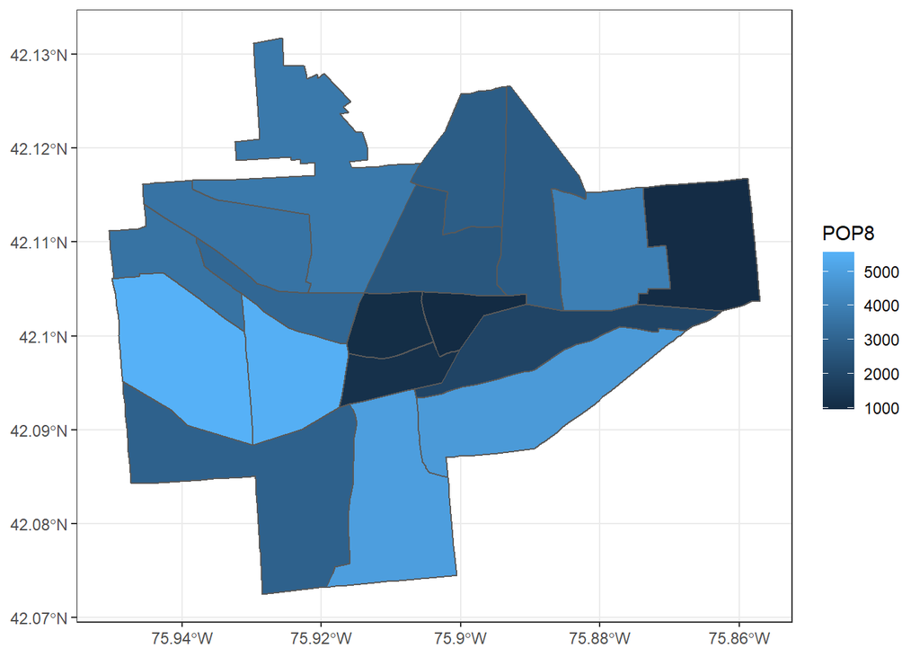

```r
ggplot() +
  geom_sf(data = binghamton, aes(fill = POP8)) +
  theme_bw()
```

##### **Manual Color Scale**

Here, we will use the `viridis` color scale, which is colorblind safe. This comes with several color palette `options`.

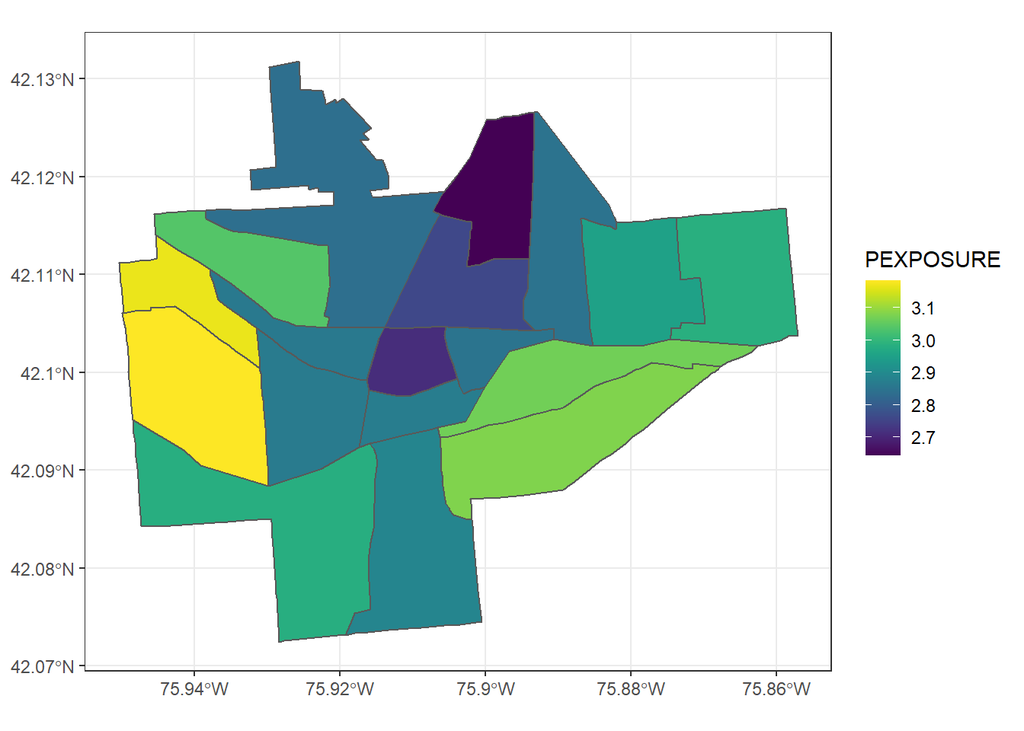

```r
ggplot() +
  geom_sf(data = binghamton, aes(fill = PEXPOSURE)) +
  scale_fill_viridis(option = "viridis") +
  theme_bw()
```

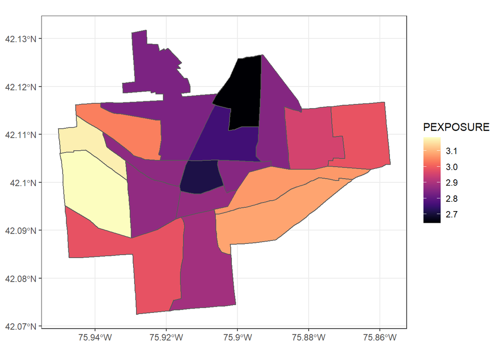

```r
ggplot() +
  geom_sf(data = binghamton, aes(fill = PEXPOSURE)) +
  scale_fill_viridis(option = "magma") +
  theme_bw()
```

##### **Coordinates**

By default, `geom_sf` transforms all `sf` objects to WGS84 (or latitude and longitude), but you can change this with `coord_sf`.

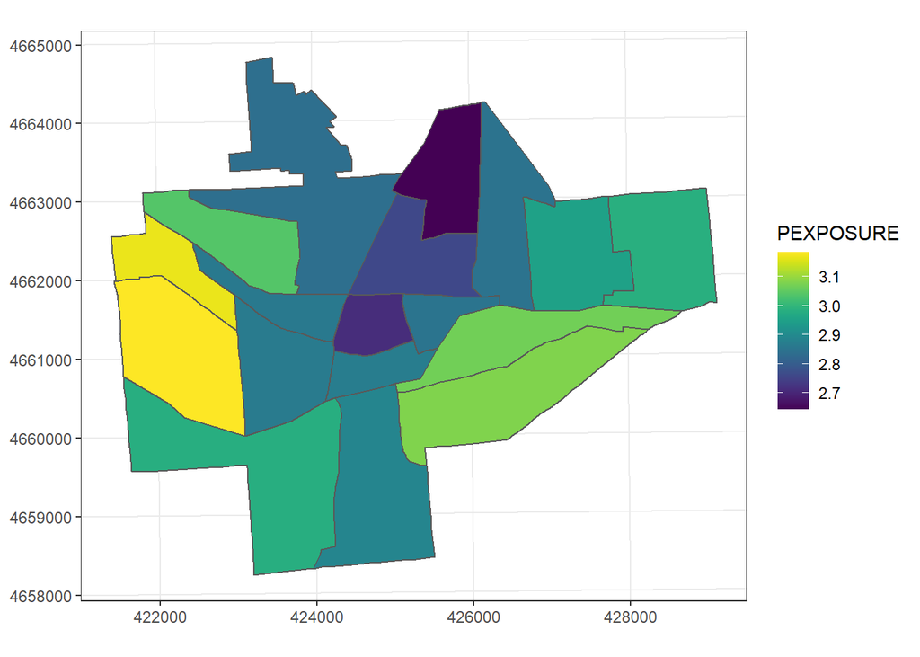

```r
ggplot() +
  geom_sf(data = binghamton, aes(fill = PEXPOSURE)) +
  scale_fill_viridis(option = "viridis") +
  coord_sf(datum = 26918) +
  theme_bw()
```

You can also use this to zoom in on different parts of the map.

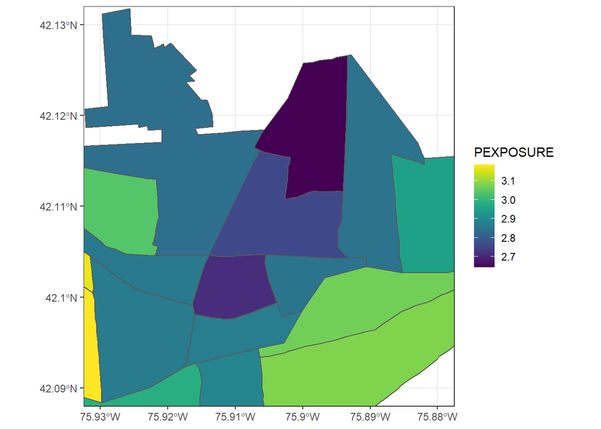

```r
ggplot() +
  geom_sf(data = binghamton, aes(fill = PEXPOSURE)) +
  scale_fill_viridis(option = "viridis") +
  coord_sf(xlim = c(-75.93, -75.88), ylim = c(42.09, 42.13)) +
  theme_bw()
```

# Rasters

Up till now, we have been working with *vector* spatial data. These are geometries composed of points defined by their coordinates. An alternative form of spatial data is known as a *raster*. This is gridded data. It takes the form of a rectangle composed of squares of equal size, which are sometimes called ‘cells’ or ‘pixels’. Each cell stores some kind of value.

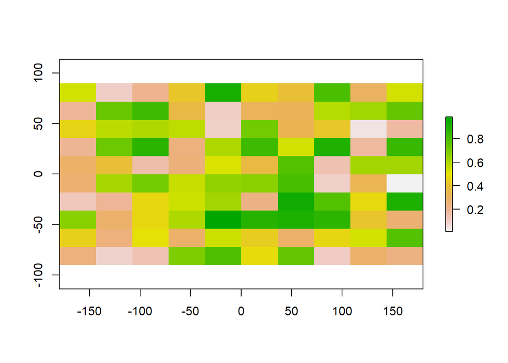

The `raster` package offers a wide array of functions for dealing with gridded data, including the ability to read from many widely used file formats, like remote sensing images (e.g. GeoTiffs), NetCDF, and HDF formats. We will use it here to work with gridded air temperature data (*air.mon.ltm.nc*) from the [NCAR NCEP reanalysis project](https://www.cpc.ncep.noaa.gov/products/wesley/reanalysis.html). This is the long term means for each month from 1981-2010. The file has 12 layers (one per month) and one variable (*air*).

### Read and Write Rasters

To read in gridded data, use the `raster()` function.

```r
air_temp <- raster("../datafiles/air.mon.ltm.nc")
```

Note that we have only read the first layer (January). R will tell you that it loaded the variable called *air*. To avoid this message you can specify this directly, which is important for files containing multiple variables:

```r
air_temp <- raster("../datafiles/air.mon.ltm.nc", varname = "air")
air_temp
```

```
## class      : RasterLayer
## band       : 1  (of  12  bands)
## dimensions : 73, 144, 10512  (nrow, ncol, ncell)
## resolution : 2.5, 2.5  (x, y)
## extent     : -1.25, 358.75, -91.25, 91.25  (xmin, xmax, ymin, ymax)
## crs        : NA
## source     : C:/Users/u0694980/Box/geog6000/datafiles/air.mon.ltm.nc
## names      : Monthly.Long.Term.Mean.Air.Temperature.at.sigma.level.0.995
## z-value    : 0000-12-30
## zvar       : air
```

Write Raster

```r
writeRaster(air_temp, filename = "../datafiles/air_temp.tif")
```

### Raster CRS

Set CRS:

```r
crs(air_temp) <- "+proj=longlat +ellps=WGS84 +towgs84=0,0,0 +no_defs "
```

Again, this should not be used to *change* the CRS, only set it.

Get CRS:

```r
crs(air_temp)
```

```
## CRS arguments:
##  +proj=longlat +ellps=WGS84 +towgs84=0,0,0,0,0,0,0 +no_defs
```

Also, note that `crs` is for rasters, `st_crs` for vectors.

Transform CRS:

```r
weird_crs <- crs("+proj=tmerc +lat_0=0 +lon_0=15 +k=0.999923 +x_0=5500000 +y_0=0 +ellps=GRS80 +units=m +no_defs")

air_temp_weird_crs <- projectRaster(air_temp, crs = weird_crs)

crs(air_temp_weird_crs)
```

```
## CRS arguments:
##  +proj=tmerc +lat_0=0 +lon_0=15 +k=0.999923 +x_0=5500000 +y_0=0
## +ellps=GRS80 +units=m +no_defs
```

Yes, `raster` still uses the PROJ4-string syntax. It’s a holdover from its original development.

### Basic Plotting

`air_temp` is a raster object and has information about grid spacing, coordinates etc. Note that the description of the object tells you whether it is held in memory (small raster files) or on disk.

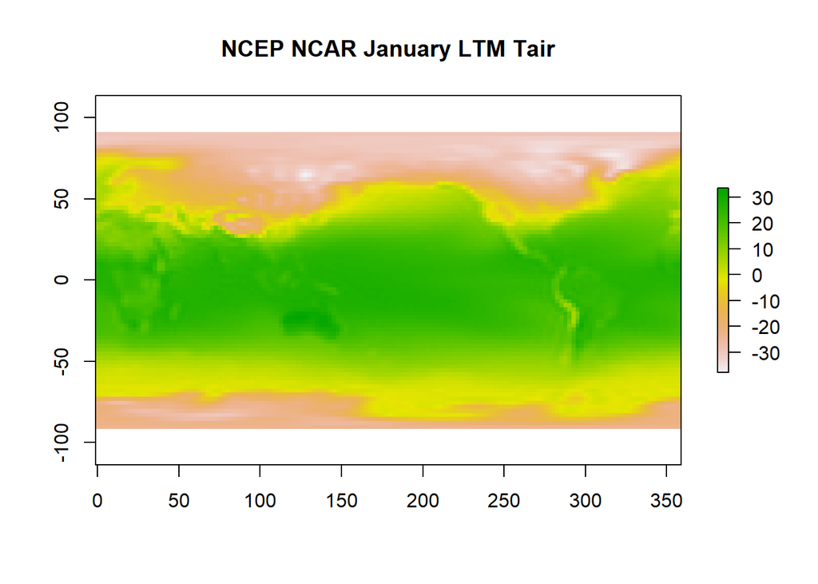

```r
plot(air_temp, main = "NCEP NCAR January LTM Tair")
```

And you should be able to see the outline of the continents. By default, NCAR NetCDF files have longitudes running from 0 to 360. We can convert this to the more commonly used (and UK-centric :) ) -180 to 180 by the function `rotate()`. We can also use a different color palette and overlay country polygons:

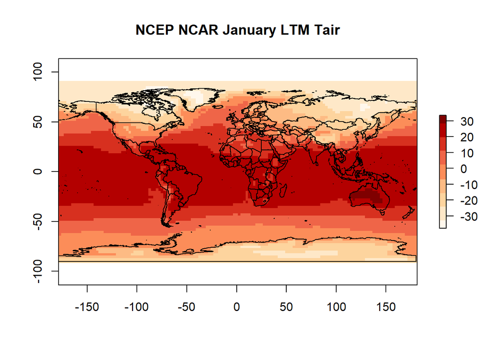

```r
air_temp = rotate(air_temp)

# using RColorBrewer
my.pal <- brewer.pal(n = 9, name = "OrRd")

plot(air_temp,
     main = "NCEP NCAR January LTM Tair",
     col = my.pal)

countries <- st_read("../datafiles/ne_50m_admin_0_countries/ne_50m_admin_0_countries.shp",
                     quiet = TRUE)

plot(st_geometry(countries), add = TRUE)
```

### Summary Statistics

The function `cellStats()` can be used to calculate most summary statistics for a raster layer. So to get the mean global temperature (and standard deviation):

```r
cellStats(air_temp, mean)
```

```
## [1] 3.546352
```

```r
cellStats(air_temp, sd)
```

```
## [1] 19.63948
```

### Subset Rasters

If we want to use only a subset of the original raster layer, the function `crop()` will extract only the cells in a given region. This can be defined using another raster object or Spatial* object, or by defining an `extent` object:

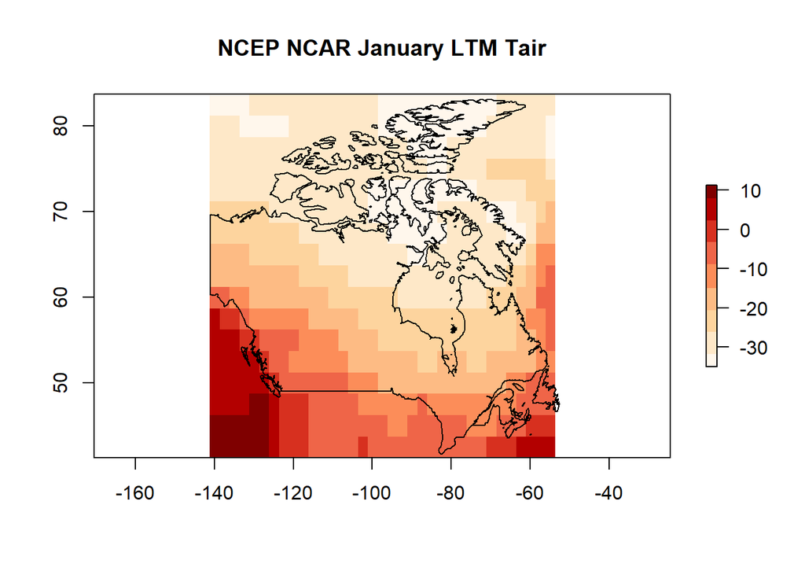

```r
# extent method
canada_ext <- extent(c(xmin = -142,
                       xmax = -52,
                       ymin = 41,
                       ymax = 84))

# this produces a slightly different result because I rounded the coordinates
canada_air_temp <- crop(air_temp, canada_ext)

# spatial method
canada <- subset(countries, NAME == "Canada")

canada_air_temp <- crop(air_temp, canada)

# plot
plot(canada_air_temp, main = "NCEP NCAR January LTM Tair", col = my.pal)

plot(st_geometry(canada), add = TRUE)
```

Note that `crop` subsets the original raster to the extent of Canada’s borders, rather than to the borders themselves. This is because rasters are *always* rectangular. You can ‘hide’ the values of raster cells outside of a polygon by using the `mask` function. The raster has to be rectangular, so this does not remove the cells outside the polygon. Rather, it sets their value to `NA`.

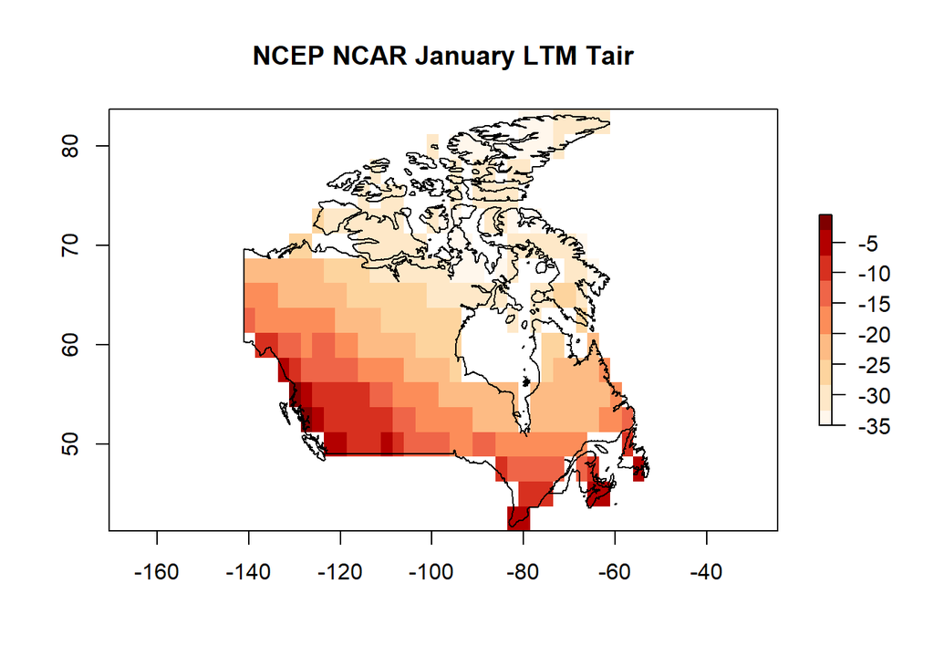

```r
canada_air_temp <- mask(canada_air_temp, mask = canada)

# plot
plot(canada_air_temp, main = "NCEP NCAR January LTM Tair", col = my.pal)

plot(st_geometry(canada), add = TRUE)
```

### Extract Data

Values can be extracted from individual locations (or sets of locations) using `extract()`. This can take a set of coordinates in matrix form, or use a Spatial* object. To get the January temperature of Salt Lake City:

```r
extract(air_temp, cbind(-111.9,40.76))
```

```
## [1] -2.919719
```

By default this gives you the value of the cell in which the point falls. The value can equally be estimated by bilinear interpolation from the four closest cells with `method='bilinear'`:

```r
extract(air_temp, cbind(-111.9,40.76), method = 'bilinear')
```

```
## [1] -4.324555
```

We created a simple feature object earlier with the location of samples in Western North America (`wna_climate`). We can now use this, and the raster layer to get the January temperature for all locations.

```r
wna_air_temp_df <- extract(air_temp,
                           wna_climate,
                           method = 'bilinear',
                           df = TRUE)

head(wna_air_temp_df)
```

```
##   ID Monthly.Long.Term.Mean.Air.Temperature.at.sigma.level.0.995
## 1  1                                                   -9.782378
## 2  2                                                  -18.523962
## 3  3                                                   -2.664617
## 4  4                                                   -7.552574
## 5  5                                                  -18.926520
## 6  6                                                  -12.687242
```

This same approach allows you to extract pixels by polygon overlays.

```r
china <- subset(countries, NAME == "China")

china_air_temp_df <- extract(air_temp, china, df = TRUE)

head(china_air_temp_df)
```

```
##   ID Monthly.Long.Term.Mean.Air.Temperature.at.sigma.level.0.995
## 1  1                                                   -23.51869
## 2  1                                                   -22.07151
## 3  1                                                   -23.53544
## 4  1                                                   -24.09268
## 5  1                                                   -21.95177
## 6  1                                                   -15.34994
```

When this function is used with a set of polygons, the output is in a list, but we can retrieve whatever we want from that list.

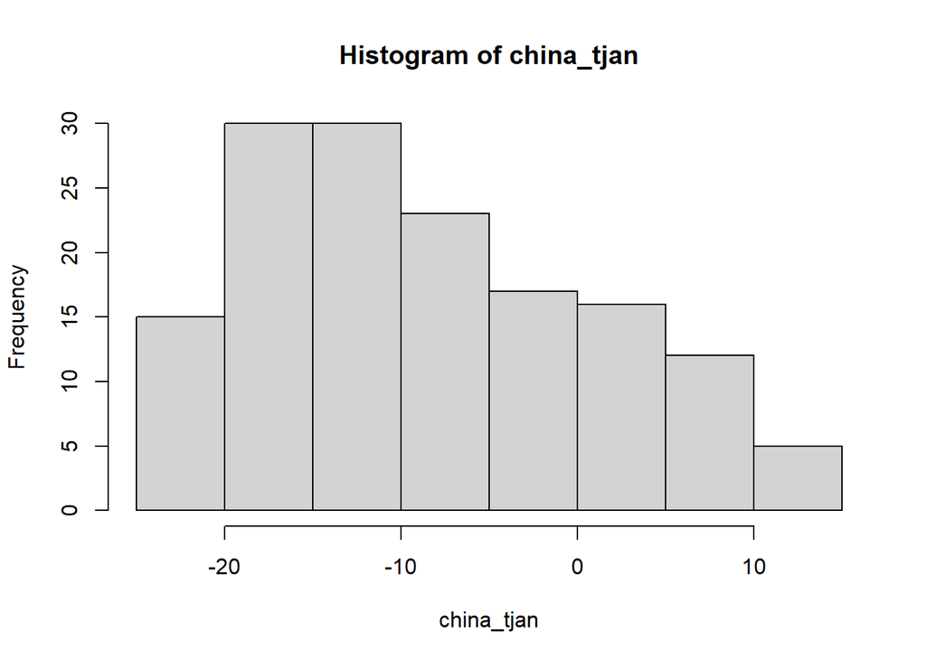

```r
two_countries <- rbind(china, canada)

china_tjan <- extract(air_temp, two_countries)[[1]]

hist(china_tjan)
```

The `extract()` function also takes an argument `fun`. This allows you to calculate a summary statistic for each set of pixels that is extracted (i.e. one per polygon). Here, we’ll use this with `countries` to get an average value of January temperature. We add this back as a new column in the countries object, and then plot it:

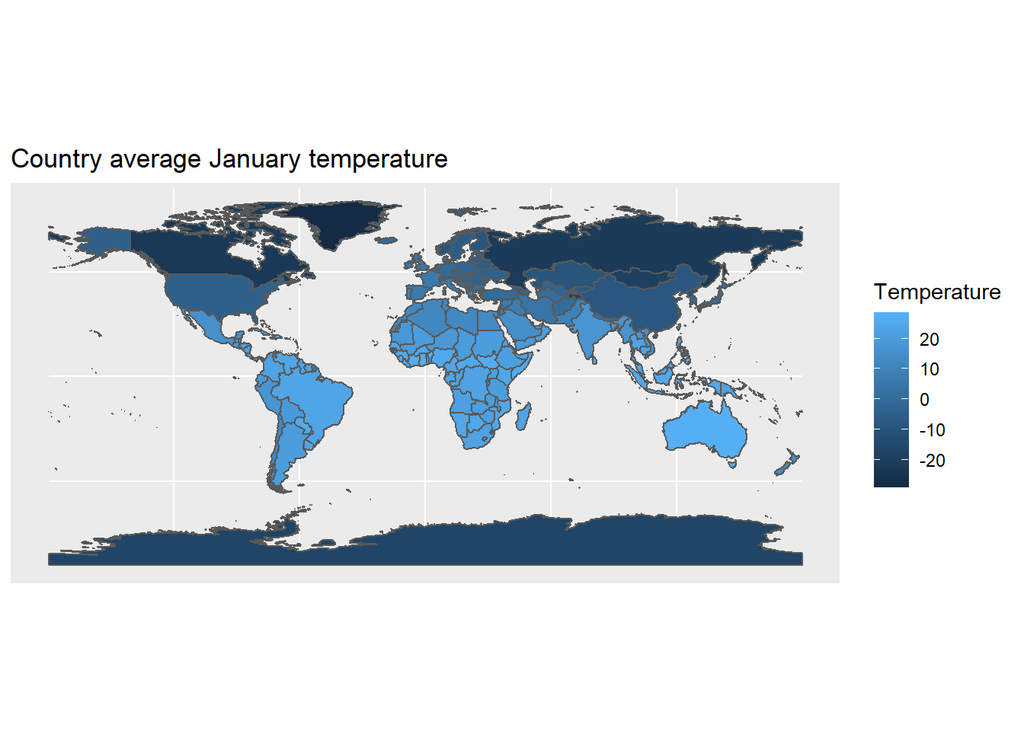

```r
countries$Jan_Tmp <- extract(air_temp, countries, fun = mean)[,1]

ggplot(countries) +
  geom_sf(aes(fill = Jan_Tmp)) +
  labs(fill = "Temperature",
       title = "Country average January temperature")
```

### Raster Stacks

A useful extension to the basic raster functions is the use of stacks. These are a stack of raster layers which represent different variables, but have the same spatial extent and resolution. We can then read in and store all 12 months from the NetCDF file, and then work with this. We read these in with `stack()` and crop them.

```r
air_temp_stk <- stack("../datafiles/air.mon.ltm.nc", varname = "air")

air_temp_stk <- rotate(air_temp_stk)

myext <- extent(c(-130,-60,25,50))

air_temp_stk <- crop(air_temp_stk, myext)
```

You can retrieve the a subset of rasters from the stack like you would values from a vector:

```r
air_temp_substk <- air_temp_stk[[1:3]]

air_temp_substk
```

```
## class      : RasterBrick
## dimensions : 10, 28, 280, 3  (nrow, ncol, ncell, nlayers)
## resolution : 2.5, 2.5  (x, y)
## extent     : -128.75, -58.75, 26.25, 51.25  (xmin, xmax, ymin, ymax)
## crs        : NA
## source     : memory
## names      : X0000.12.30, X0001.01.30, X0001.02.27
## min values :   -18.18637,   -15.90084,   -10.40882
## max values :    21.45181,    21.01648,    21.04738
## time       : 0000-12-30, 0001-01-30, 0001-02-27
```

```r
names(air_temp_stk) <- paste("TAS", month.abb)

names(air_temp_stk)
```

```
##  [1] "TAS.Jan" "TAS.Feb" "TAS.Mar" "TAS.Apr" "TAS.May" "TAS.Jun" "TAS.Jul"
##  [8] "TAS.Aug" "TAS.Sep" "TAS.Oct" "TAS.Nov" "TAS.Dec"
```

And now you can also pull out rasters by name:

```r
# method 1
air_temp_jan <- air_temp_stk$TAS.Jan

# method 2
air_temp_jan <- air_temp_stk[["TAS.Jan"]]
```

A useful feature of raster stacks is that any of the functions we used previously with one layer will be used across all layers when applied to the stack. The `plot()` function, for example, returns a grid with one plot per layer. Setting the `zlim` argument ensures that all figures use the same range of colors:

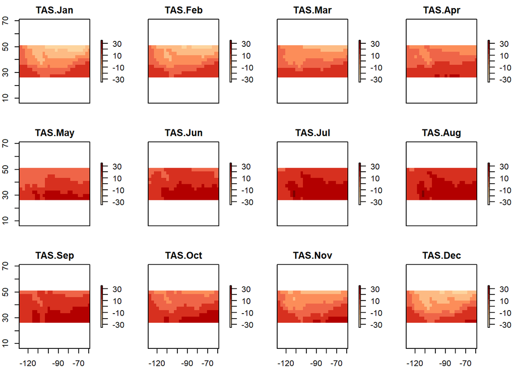

```r
plot(air_temp_stk,
     col = my.pal,
     zlim = c(-35, 35))
```

Adding a shapefile (or other spatial information) is a little more complex. We create a simple function to plot the country borders, then include this as an `addfun` in the call to `plot()`:

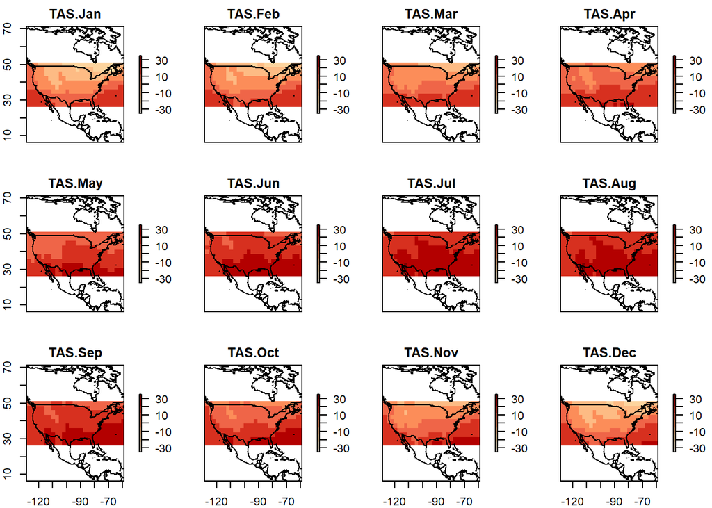

```r
addBorder = function(){ plot(as_Spatial(countries), add = TRUE) }

plot(air_temp_stk,
     col = my.pal,
     zlim = c(-35,35),
     addfun = addBorder)
```

The `cellStats()` function now returns the mean (or other statistic) for all layers, allowing a quick look at the seasonal cycle of average air temperature.

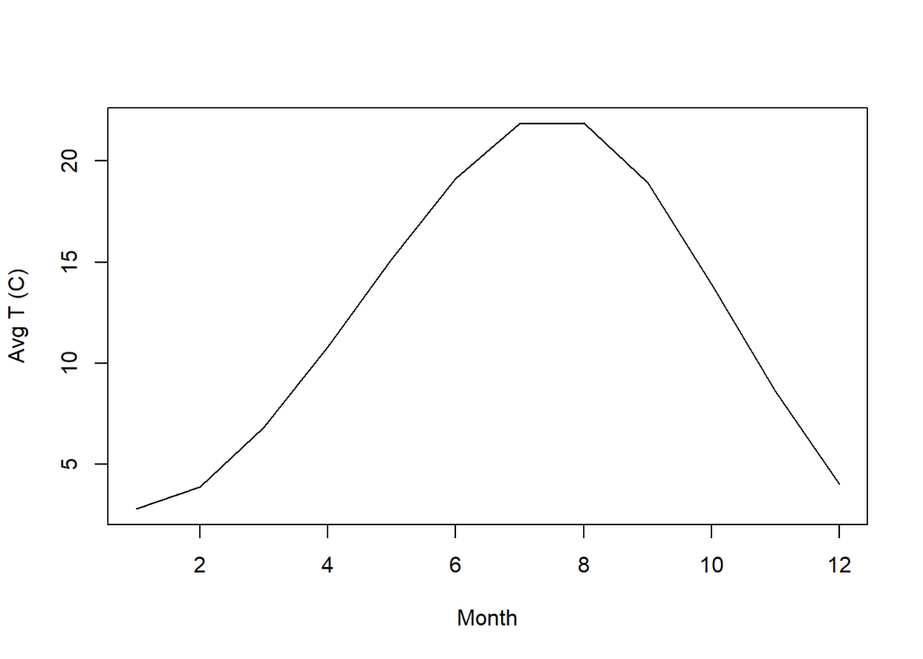

```r
tavg <- cellStats(air_temp_stk, mean)

plot(1:12, tavg,
     type = 'l',
     xlab = "Month",
     ylab = "Avg T (C)")
```

And we can do the same for an individual location using `extract()`:

```r
slc.tavg <- extract(air_temp_stk, cbind(-111.9,40.76), method = 'bilinear')

plot(1:12,
     slc.tavg,
     type = 'l',
     xlab = "Month",
     ylab = "Avg T (C)")
```

[output not shown]

# Appendix A: `tmap`

[`tmap`](https://mtennekes.github.io/tmap/) is built on top of `ggplot2` and works in a similar way by building a series of layers with map geometries and elements. We start by using `tm_shape()` to identify the spatial object to be used, and then geometries are added, including filled polygons, borders, legends, etc.

We’ll start by making some maps with the Syracuse dataset we made earlier. First, let’s make a simple map showing the polygon outlines using `tm_borders()`:

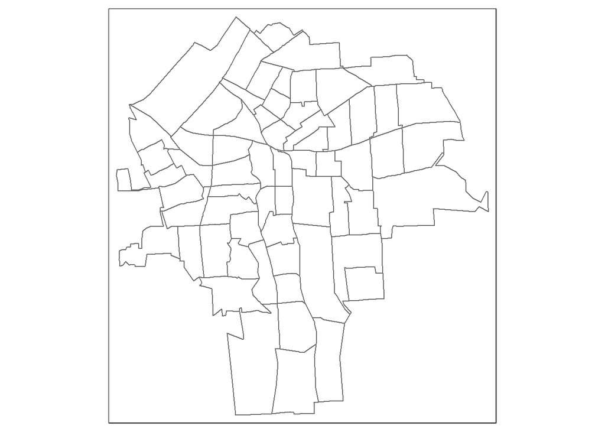

```r
Syracuse <- NY8[NY8$AREANAME == "Syracuse city", ]

tm_shape(Syracuse) + tm_borders()
```

The function `tm_fill()` will then fill these using one of the variables in the Syracuse data set (POP8). Note that this automatically adds a legend within the frame of the figure:

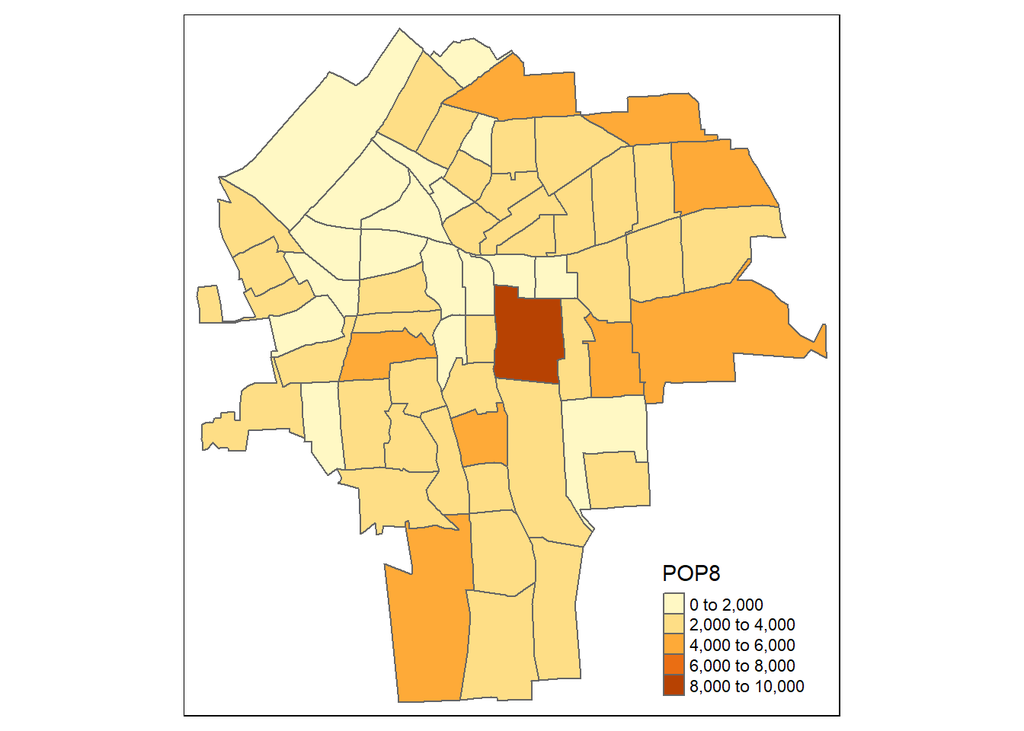

```r
tm_shape(Syracuse) +
  tm_borders() +
  tm_fill("POP8")
```

The color scale can be changed by setting the `palette` argument in `tm_fill()`. This includes the ColorBrewer scales described above,and the different intervals. For example, to use the ‘Greens’ palette with percentile breaks:

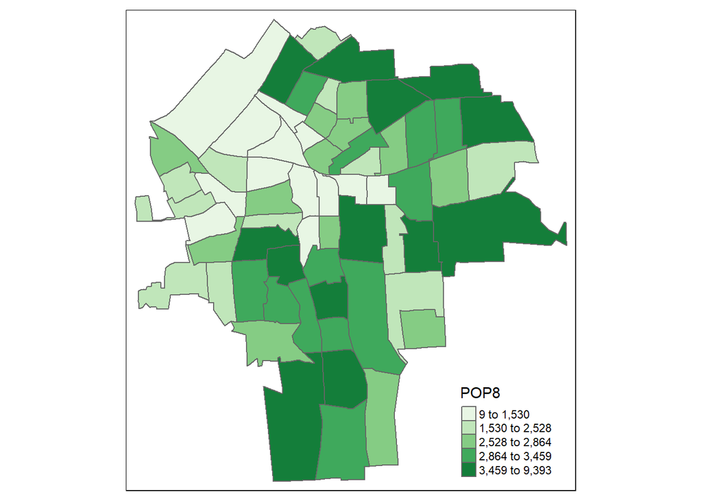

```r
tm_shape(Syracuse) +
  tm_borders() +
  tm_fill("POP8", palette = "Greens", style = "quantile")
```

Other map elements can be added. Here we add a longitude/latitude graticule with `tm_graticules()`, a north arrow and a line of text with the date the map was made.

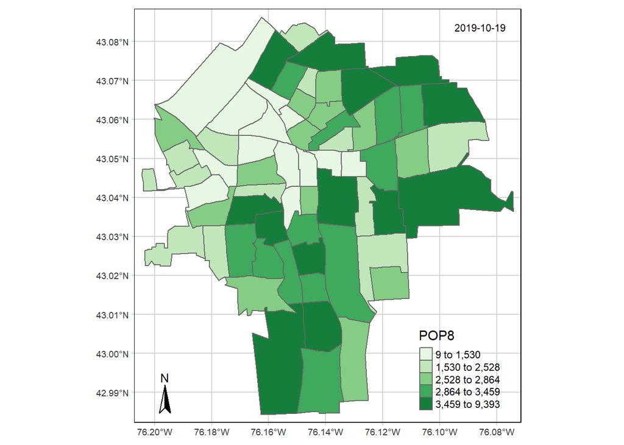

```r
tm_shape(Syracuse) +
  tm_graticules(col = "lightgray") +
  tm_borders() +
  tm_fill("POP8", palette = "Greens", style = "quantile") +
  tm_compass(position = c("left", "bottom")) +
  tm_credits("2019-10-19", position = c("right", "top"))
```

# Appendix B: Interactive Maps